# Week 3 - Introduction to Data Analysis

ETC1010-5510

# Exercise 1: Data Visualisation and Lubridate

> Open data-viz1.Rmd

### Load packages

```r
library(readr)
library(rwalkr)
library(lubridate)
library(tidyverse)
```

## Answer the following questions:

## Section A: Play with dates

### Convert something of the format “2020-01-20” into a date?

```r
ymd("2020-01-20")
```

```
## [1] "2020-01-20"
```

### How do you show today’s date?

```r
now()
```

```
## [1] "2021-03-16 01:04:03 UTC"
```

### Q1. Convert something of the format “2020-01-20 10:00:01” into a date time? Try function: `ymd_hms()`

```r
a <- c("2020-01-20 10:00:01")
b <- ymd_hms("2020-01-20 10:00:01")
class(a)
```

```
## [1] "character"
```

```r
class(b)
```

```
## [1] "POSIXct" "POSIXt"
```

### Q2. Get the weekday and name of weekday out of “2020-01-20”. Try `wday()`

```r
wday("2020-01-20")
```

```
## [1] 2
```

```r
wday("2020-01-20", label=T)
```

```
## [1] Mon
## Levels: Sun < Mon < Tue < Wed < Thu < Fri < Sat
```

### Q3. Get the month and month name out of “2020-01-20”. Try `label`

```r
month("2020-01-20")
```

```
## [1] 1
```

```r
month("2020-01-20", label = TRUE)
```

```
## [1] Jan
## 12 Levels: Jan < Feb < Mar < Apr < May < Jun < Jul < Aug < Sep < ... < Dec
```

### Q4. Get the un-abbreviated month name out of “2020-01-20”

```r
month("2020-01-20", label = TRUE, abbr  = FALSE)
```

```
## [1] January
## 12 Levels: January < February < March < April < May < June < ... < December
```

### Q5. Get the day of the year out of “2020-01-20”. Try `yday()`

```r
yday("2020-01-20")
```

```
## [1] 20
```

## Section B: Data Visualisation

### Load data

```r
walk_tidy <- read_csv(file = "data/walk-feb-march-2020.csv.gz")
```

### Q1. Make a side-by-side boxplot of pedestrian counts by sensor. Use `Count` and `Sensor` in aesthetics.

> Make sure to load the ggplot2 library

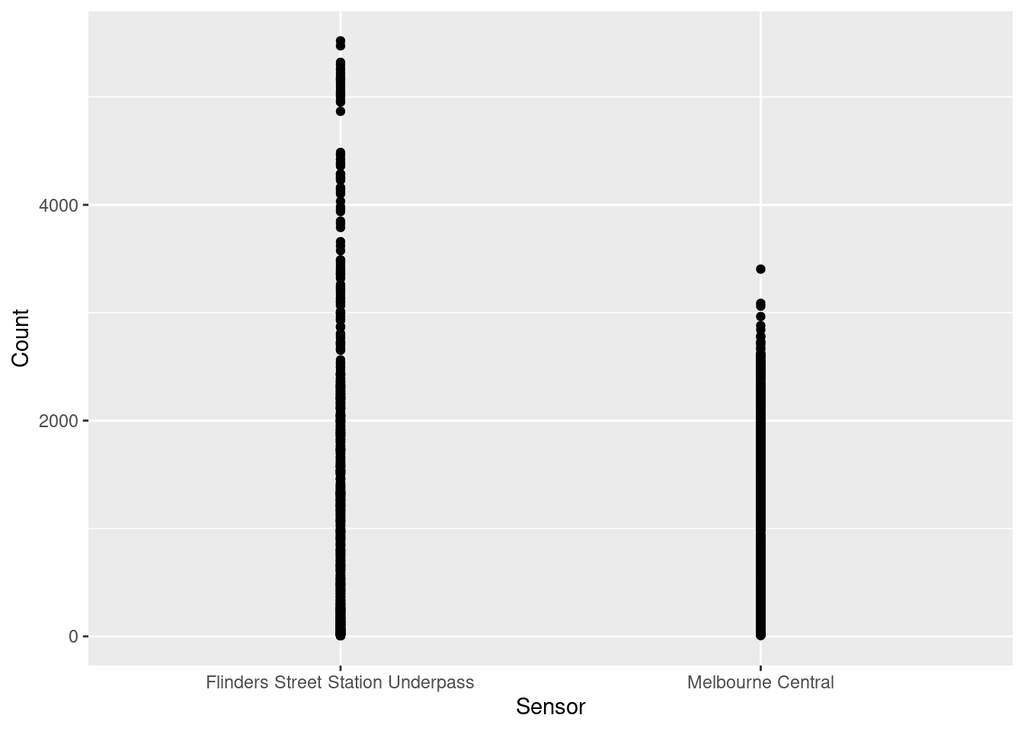

```r
library(ggplot2)
ggplot(walk_tidy,
       aes(x = Sensor,
           y = Count)) +
  geom_point()
```

> There are many observations presented with `geom_point()`!

### Q2. Try using `geom_boxplot()` instead to summarise this information.

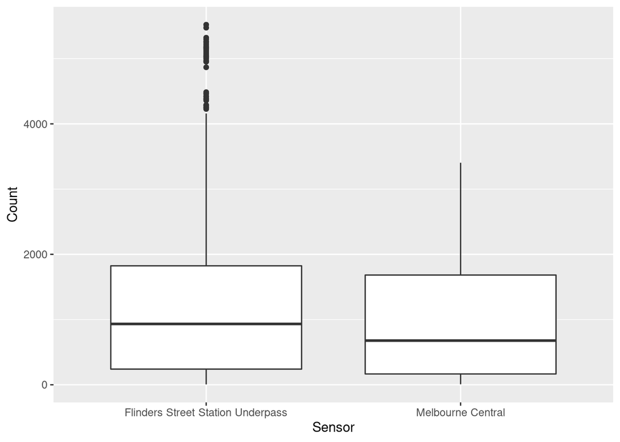

```r
ggplot(walk_tidy,
       aes(x = Sensor,
           y = Count)) +
  geom_boxplot()
```

> Describe what you learn from the boxplot.

> The distribution of pedestrian counts seem to overlap with each other, given the 2 boxes lie so close to each other. Flinder’s Underpass has a higher median pedestrian Counts and contain outliers as compared to Melbourne Central (no outliers). Need more information/in-depth analysis to draw insights from the data!

> Hint - read the previous description of the `dmy` function to work out how to choose the date.

```r
walk_first_march <- walk_tidy %>%
  filter(Date >= dmy("01-03-2020"),
         Date <= dmy("08-03-2020"))
```

### Q4. Using the first week data, make line plots of `Count` by `Date_Time`, separately for each sensor.

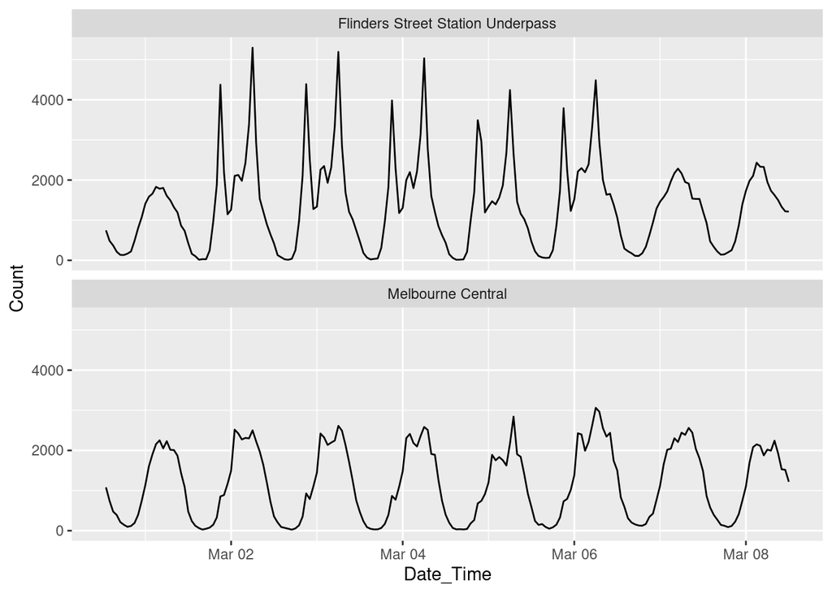

```r
ggplot(walk_first_march,
       aes(x = Date_Time,
           y = Count)) +
  geom_line() +
  facet_wrap(~Sensor,
             ncol = 1)
```

> What do you learn? Explain the patterns.

> Time Series graph from pedestrian counts in Melbourne Central Station stay the same throughout the first week of March. The pattern at Flinders Street Station however, is different for Weekdays and Weekends. The weekends lack the two-distinct peaks corresponding to morning and evening rush-hours.

> Now, go to `knitr::opts_chunk` at line 9, change `eval = TRUE`, then knit the document.

# Appendix: Code using which the data was obtained.

## Reading in the data

**(Note that the code chunk below is set to `eval = FALSE`, which means that it will not run when you knit the document.)**

### Explanation of reading / tidying code

- First we use `library(rwalkr)` to load up the libraries that are needed to download the pedestrian tracking data - this is the `rwalkr` R package
- Then we load the `lubridate` R package with `library(lubridate)`. Lubridate is an R package that we will cover in more detail in the next lecture. For the moment all you need to know about is the `dmy()` function, which takes a character input (like “20-03-2020”) and converts it into a special date format.
- You can explore what this format is by looking at the `start_date` and `end_date` objects.
- Here we are using the foramt: “ddmmyyy”, where there are two digits for the day, two digits for the month and four for the year.
- So, “01012000” would be the First of January, 2000.

```r
 # library(rwalkr)
 # library(lubridate)
 # library(tidyverse)
 #
 # start_date <- dmy("01-02-2020")
 # end_date <- dmy("30-03-2020")
 #
 # walk_raw <- melb_walk(from = start_date,
 #                       to = end_date)
```

There are many sensors that are measured by the pedestrian tracking system. You can find out more information about the data by looking up the helpfil for the `melb_walk` function by typing `?melb_walk`.

We want to `filter` the data based on the sensor, and only look at two: Melbourne Central, and the Flinders Street Station Underpass. We need to make sure we have loaded the `dplyr` library

```r
 # library(dplyr)
 # walk_tidy <- walk_raw %>%
 #   filter(Sensor %in% c("Melbourne Central",
 #                        "Flinders Street Station Underpass"))
```

```r
 # library(readr)
 # write_csv(walk_tidy,
 #           path = "data/walk-feb-march-2020.csv.gz")
 #
 # write_csv(walk_raw,
 #           path = "data/walk_raw.csv.gz")
```